# Report 1

Klaus Schliep

2025-11-24

## Report Guidelines

### The front page has to include:

- Your Names (Groups up to 3)
- Your matriculation numbers
- Name of the Report/Lab

### The Report has to include:

- Answers to questions below.
- Answer the questions in full sentences
- Add relevant plots and tables and describe how you got your results.
- Include the function and the variables/data objects you used, or the field name of the output
- Include relevant plots/figures (you can either use screenshots )
- Plots and tables need to have a capture describing what is shown.(E.g.: Figure 1: Dotplot of the ORA analysis, showing the 10 most significantly overrepresented biological processes within downregulated genes.)

### Expected Format:

- 1 PDF file and maybe additionally an R / Rmarkdown file.
- Only one person has to hand in the report per group
- (You can use a program of your choice to generate this e.g. Microsoft Word or R/ R markdown)

For further questions, write me an email or find me on the 5th floor of Petersgasse 14, Room BK04060 (Tue, Thu, Fr).

## Questions

We will go through he process of a phyloigenetic analysis:

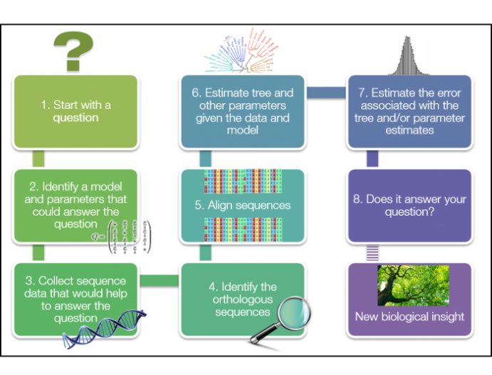

We will use the data FAP, we briefly used before.

1. First search on NCBI for additional FAP sequences with Blastp using the accession number `XP_001703004`. Download 25 additional sequences and save them in the folder data_raw as FAP_BLAST.fas.
2. Read in the data and combine the two unaligned data sets: You can either do this in R or add the sequences in a file together.

```r
library(ape)
library(phangorn)
library(msa)
FAP <- read.FASTA("data_raw/FAP_genbank.fas")
FAP_blast <- read.FASTA("data_raw/FAP_BLAST.fas")

FAP_all <- c(FAP, FAP_blast)
```

There might be duplicated sequences in the `FAP_all` object. Delete the duplicates and save the file in the data folder as file `FAP_all.fas`. How many duplicated sequences did you have in your file?

```
duplicated(FAP_all)
FAP_all <- FAP_all[!duplicated(FAP_all)]
write.FASTA(..., ...)
```

2. Align the sequences:

You can either do this in R or online https://www.ebi.ac.uk/jdispatcher/msa

```
FAP_aligned <- msaClustalOmega(...)
FAP_aligned <- as.AAbin(FAP_aligned)
write.FASTA(FAP_aligned, "data/FAP_aligned.fas")
```

3. Phylogenetic Analysis

First perform modelTest:

```
FAP_pd <- read.phyDat("data/FAP_aligned.fas", format= ..., type= ...)
mt <- modelTest(FAP_pd)
fit <- pml_bb(mt)
```

- What is the best fitting model?
- plot the maximum likelihood tree!
4. Extra

Perform a phylogenetic analysis with [iqtree](http://iqtree.cibiv.univie.ac.at/).

- Are the models of phangorn and iqtree the same?
- How do the ML trees differ?